# homework

Isabella Muratore

# homework 02

## What is the probability that she will hear more than 8 calls during any given session?

### using a poisson probability distribution to get the upper tail using 8 position along the distribution.

```r
ppois(8, lambda=15, lower=FALSE)
```

```
## [1] 0.9625535
```

#### returns ~0.96, so the answer is a ~96% probability of more than 8 assuming the mean is accurate

## What is the probability that she will hear no calls in a session?

### using a poisson density distribution (since this is just for one specific value) to get the probability of hearing exactly 0 calls (you could also do this with ppois at position 0 capturing the lower tail)

```r
dpois(0, lambda=15)
```

```
## [1] 3.059023e-07
```

#### returns 0.0000003059023, so a 0.00003059023% probability, quite unlikely

## What is the probability that she will hear exactly 3 calls in a session?

### using a poisson density distribution (since this is just for one specific value) to get the probability of hearing exactly 3 calls

```r
dpois(3, lambda=15)
```

```
## [1] 0.0001720701
```

#### returns 0.0001720701, so 0.01720701% probability, also unlikely

## Plot the relevant Poisson mass function over the values in range 0 ≤ x ≤ 30

### Using dpois from 0 to 30 and plotting as points over x = a vector from 0 to 30

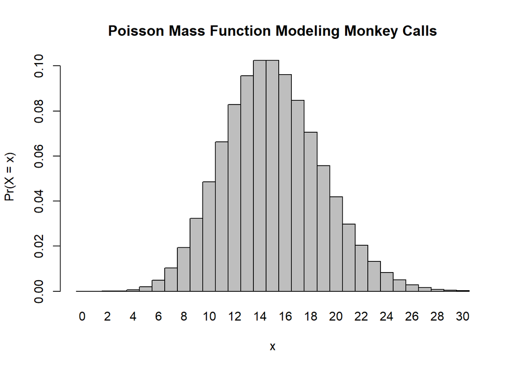

```r
z <- dpois(0:30, lambda=15)

x <- c(0:30)

barplot(z, names.arg = x, space = 0, xlab = "x", ylab = "Pr(X = x)", main = "Poisson Mass Function Modeling Monkey Calls")
```

#### this creates a smooth looking distribution

## Simulate 104 results from this distribution (i.e., 2 years of Saturday monitoring sessions).

### Using rpois to generate 104 random numbers from a poisson distribution with lambda 15

```r
x <- rpois(104, lambda=15)

x
```

```
##   [1] 16 17 13 12 20 13 12 12 16 15 15 13 16 18 15 11 15 16 12 12 16 21 17
##  [24] 24 14 12  7 20 11 14 11 16 11 16  8 15 18 11 14 17 17  9 17 21 11 16
##  [47] 21 11 15 19 15 22 13 11 19 23 18 13 12 12 14 12 18 11 17 12 13 20 23
##  [70]  7 13 19 11 17 10 19 13 15 13 16 17  9 24 12 12 11 11 15 11 12 18 14
##  [93] 13 13 13 10 17  8 11 12 21 13 22 13
```

#### returns a vector of numbers

## Plot the simulated results using hist() and use xlim() to set the horizontal limits to be from 0 to 30. How does your histogram compare to the shape of the probability mass function you plotted above?

### applying hist() with an x range of 0-30 to “x”, which we filled with random poisson numbers above

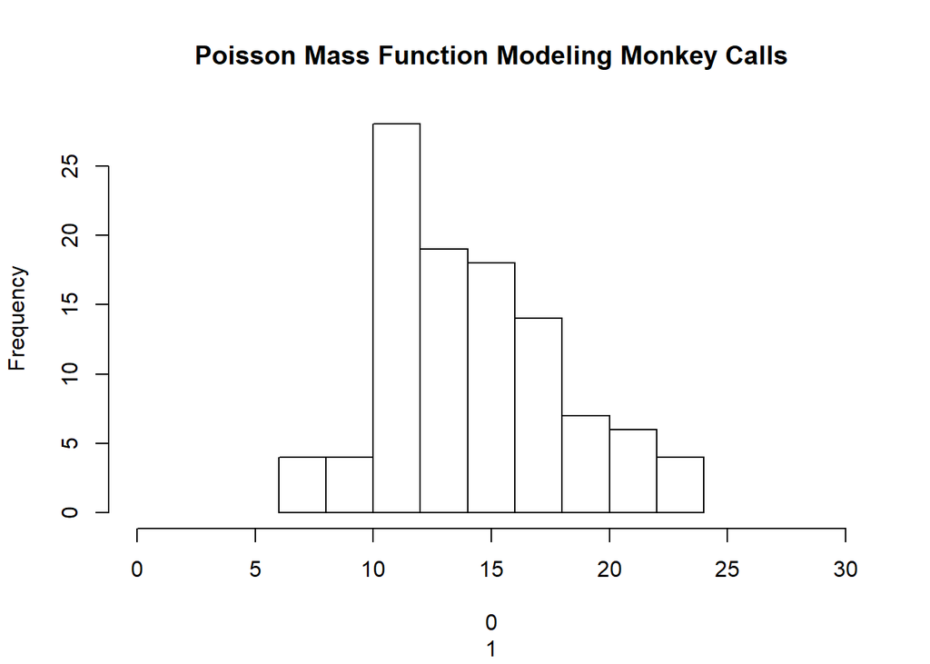

```r
hist(x, xlim=range(c(0:30)), xlab=c(0:30), main="Poisson Mass Function Modeling Monkey Calls")
```

#### This distribution is much less smooth and symmetrical than the one made using the probability mass function. The probability mass function histogram is more “perfect” because it represents the entire infinitely divisible distribution, as opposed to showing 104 discrete elements from the distribution, and larger sample size tightens the distribution and decreases variance/standard deviation because n is in the denominator of these equations.

# second homework problem (please ignore for now)

## Load in the dataset “zombies.csv” from my GitHub repo

### downloading zombies.csv from GitHub using curl, formatting using read.csv with commas as separation

```r
library(curl)
f <- curl("https://raw.githubusercontent.com/fuzzyatelin/fuzzyatelin.github.io/master/AN597_Fall17/zombies.csv")

d <- read.csv(f, header = TRUE, sep = ",", stringsAsFactors = FALSE)
head(d)
```

```
##   id first_name last_name gender   height   weight zombies_killed
## 1  1      Sarah    Little Female 62.88951 132.0872              2
## 2  2       Mark    Duncan   Male 67.80277 146.3753              5
## 3  3    Brandon     Perez   Male 72.12908 152.9370              1
## 4  4      Roger   Coleman   Male 66.78484 129.7418              5
## 5  5      Tammy    Powell Female 64.71832 132.4265              4
## 6  6    Anthony     Green   Male 71.24326 152.5246              1
##   years_of_education                           major      age
## 1                  1                medicine/nursing 17.64275
## 2                  3 criminal justice administration 22.58951
## 3                  1                       education 21.91276
## 4                  6                  energy studies 18.19058
## 5                  3                       logistics 21.10399
## 6                  4                  energy studies 21.48355
```

## Calculate the population mean and standard deviation for each quantitative random variable (height, weight, age, number of zombies killed, and years of education). NOTE: You will not want to use the built in var() and sd() commands as these are for samples.

### using mean function to average the height variable

```r
#aggregate(d$Body_mass_female_mean ~ d$Family, FUN = "mean", na.rm = TRUE)

h <- d$height

mean(h)
```

```
## [1] 67.6301
```

```r
w <- d$weight

mean(w)
```

```
## [1] 143.9075
```

```r
a <- d$age

mean(a)
```

```
## [1] 20.04696
```

```r
z <- d$zombies_killed

mean(z)
```

```
## [1] 2.992
```

```r
y <- d$years_of_education

mean(y)
```

```
## [1] 2.996
```

```r
pop_v <- function(x) {
    sum((x - mean(x))^2)/(length(x))
}
```

```r
pop_sd <- function(x) {
    sqrt(pop_v(x))
}
pop_sd(h)
```

```
## [1] 4.30797
```

```r
pop_sd(w)
```

```
## [1] 18.39186
```

```r
pop_sd(a)
```

```
## [1] 2.963583
```

```r
pop_sd(z)
```

```
## [1] 1.747551
```

```r
pop_sd(y)
```

```
## [1] 1.675704
```

## Use {ggplot} and make boxplots of each of these variables by gender.

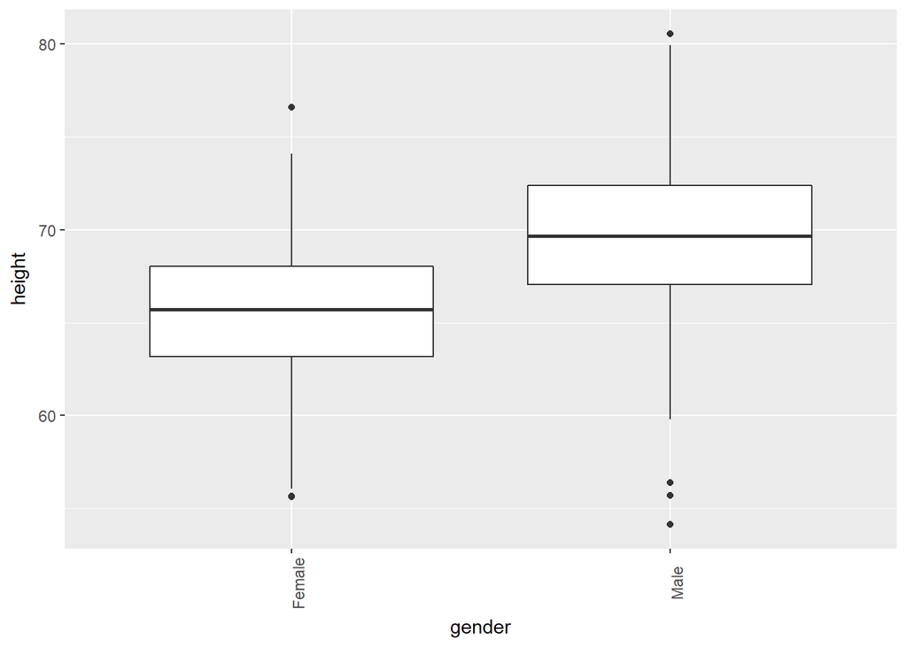

```r
library(ggplot2)

p <- ggplot(data = d, aes(x = gender, y = h))
p <- p + geom_boxplot()
p <- p + theme(axis.text.x = element_text(angle = 90))
p <- p + ylab("height")
p
```

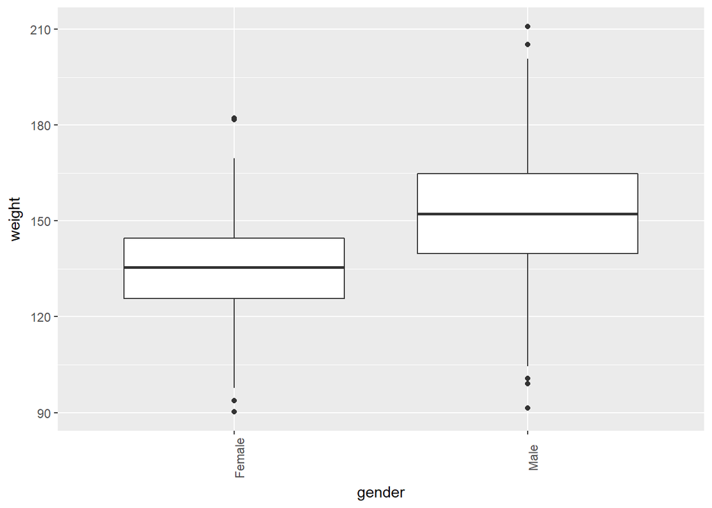

```r
p <- ggplot(data = d, aes(x = gender, y = w))
p <- p + geom_boxplot()
p <- p + theme(axis.text.x = element_text(angle = 90))
p <- p + ylab("weight")
p
```

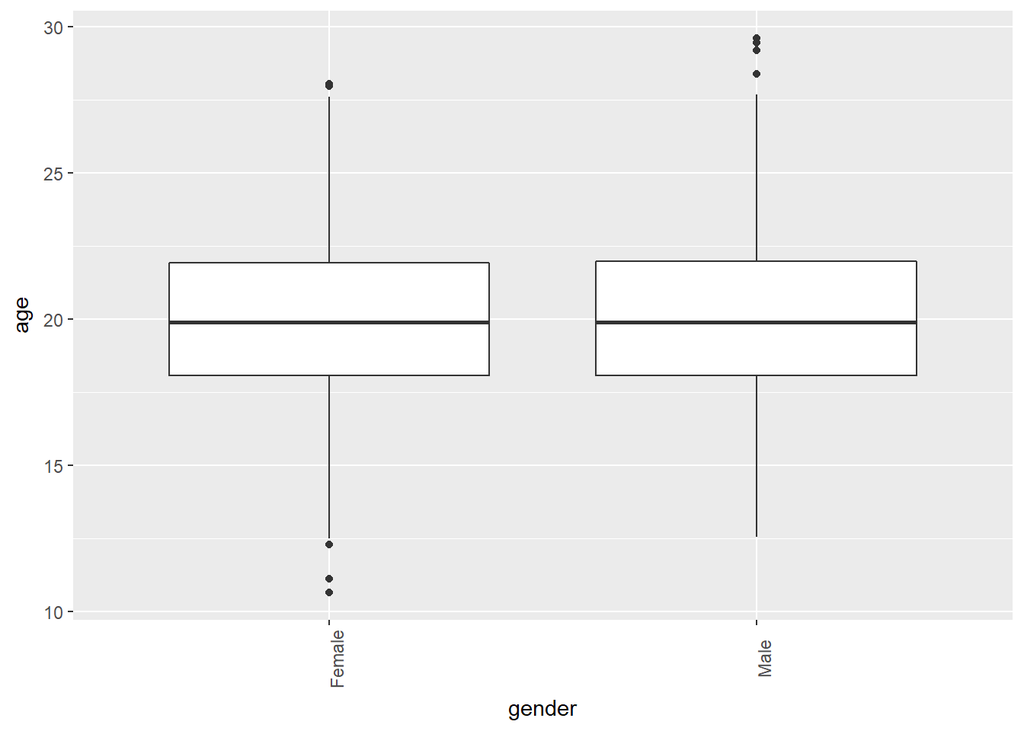

```r
p <- ggplot(data = d, aes(x = gender, y = a))
p <- p + geom_boxplot()
p <- p + theme(axis.text.x = element_text(angle = 90))
p <- p + ylab("age")
p
```

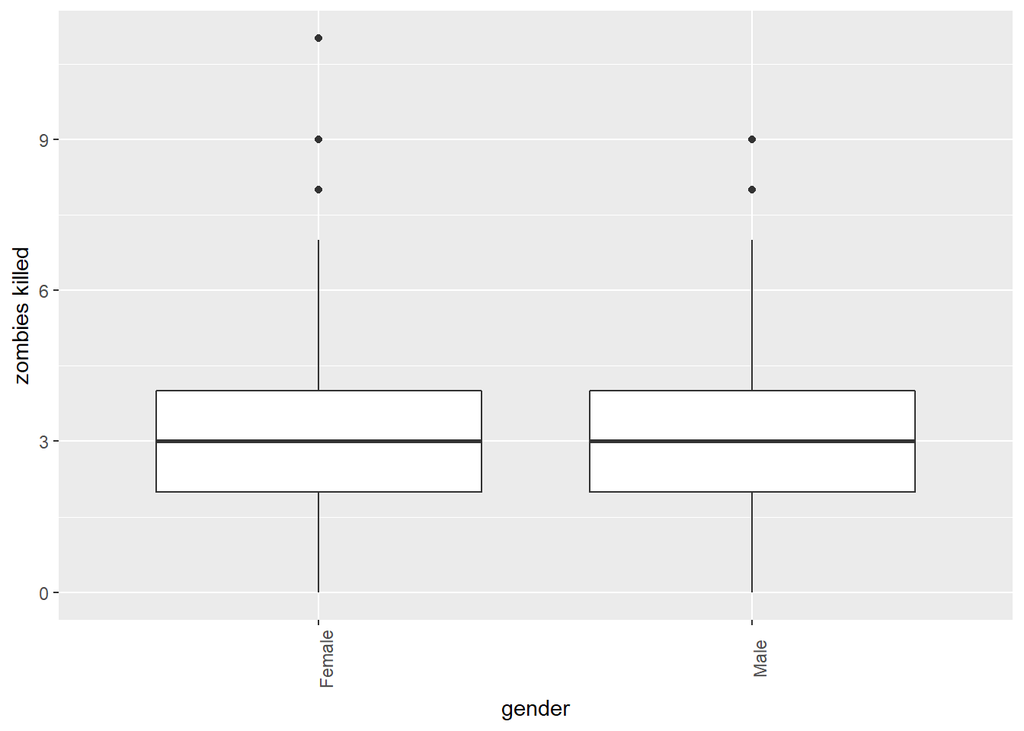

```r
p <- ggplot(data = d, aes(x = gender, y = z))
p <- p + geom_boxplot()
p <- p + theme(axis.text.x = element_text(angle = 90))
p <- p + ylab("zombies killed")
p
```

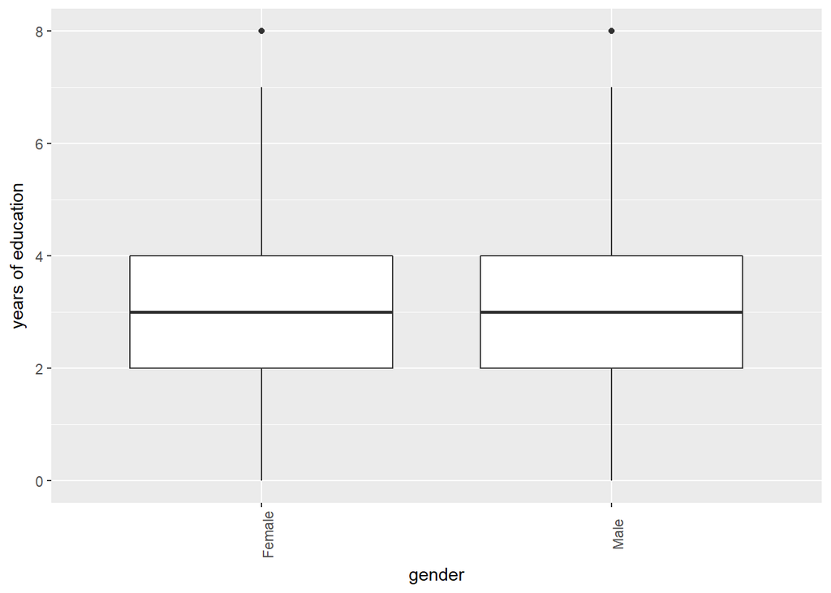

```r
p <- ggplot(data = d, aes(x = gender, y = y))
p <- p + geom_boxplot()
p <- p + theme(axis.text.x = element_text(angle = 90))
p <- p + ylab("years of education")
p
```

## Use {ggplot} and make scatterplots of height and weight in relation to age. Do these variables seem to be related? In what way?

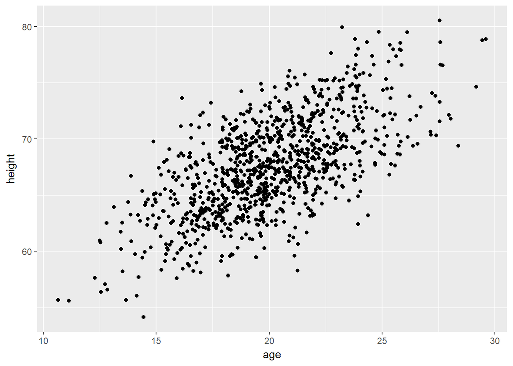

```r
p <- ggplot(data = d, aes(x = age, y = height))  # first, we build a plot object
p <- p + xlab("age") + ylab("height")  # then we modify the axis labels
p <- p + geom_point()  # then we make a scatterplot
p <- p + theme(legend.position = "bottom", legend.title = element_blank())  # then we modify the legend
p  # and, finally, we plot the object
```

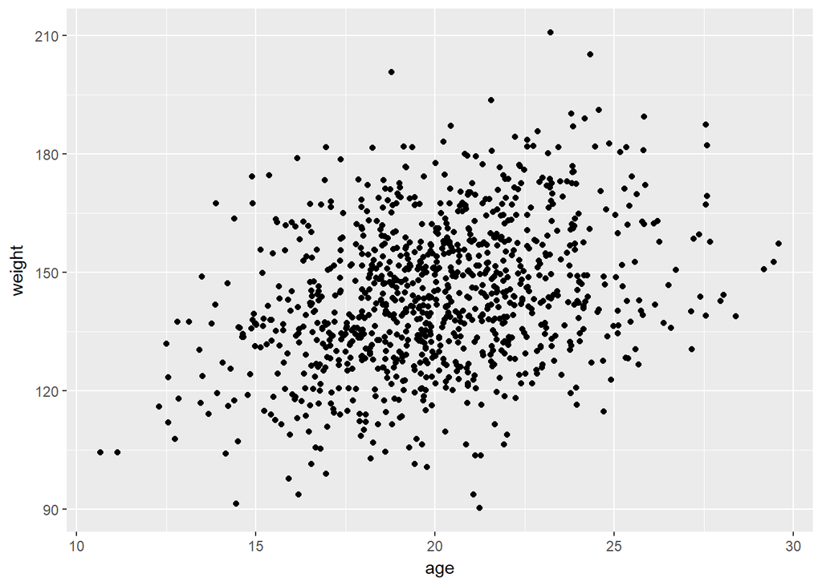

```r
p <- ggplot(data = d, aes(x = age, y = weight))  # first, we build a plot object
p <- p + xlab("age") + ylab("weight")  # then we modify the axis labels
p <- p + geom_point()  # then we make a scatterplot
p <- p + theme(legend.position = "bottom", legend.title = element_blank())  # then we modify the legend
p  # and, finally, we plot the object
```

#### Without quantifying correlation, I would say that both height and weight are positively correlated to age, with the correlation between weight and age appearing slightly less robust than that between height and age.

## Using histograms and Q-Q plots, check whether the quantitative variables seem to be drawn from a normal distribution. Which seem to be and which do not (hint: not all are drawn from the normal distribution)? For those that are not, can you determine what common distribution they are drawn from?

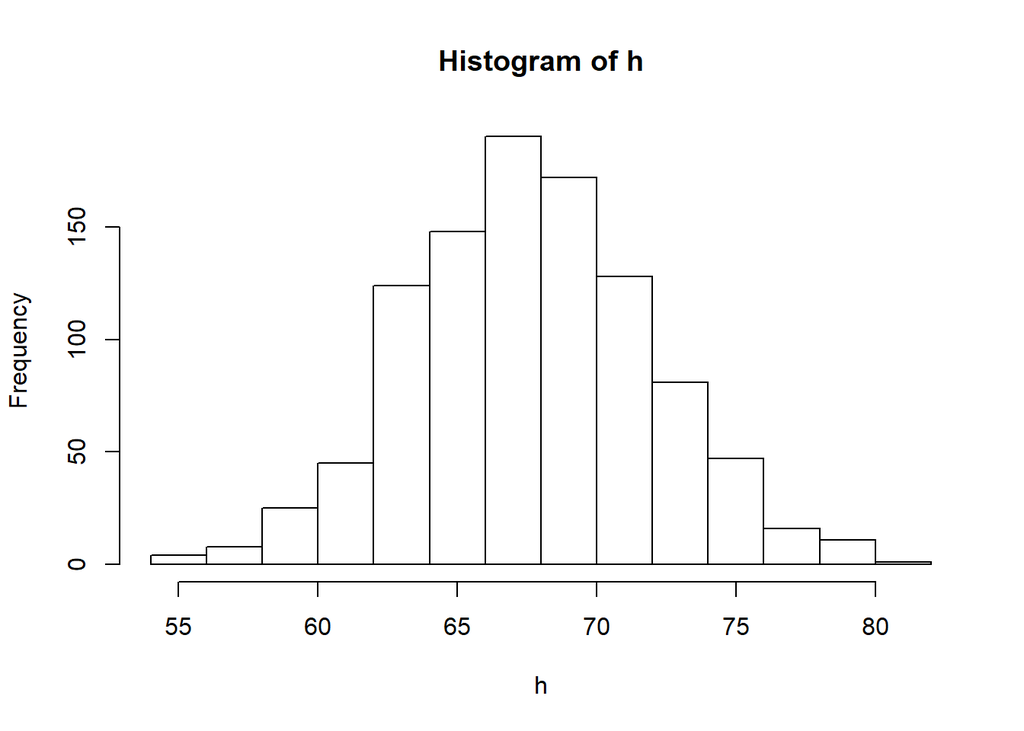

```r
hist(h)
```

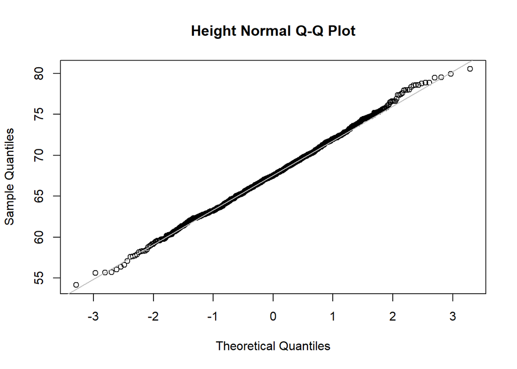

```r
qqnorm(h, main = "Height Normal Q-Q Plot")
qqline(h, col = "gray")
```

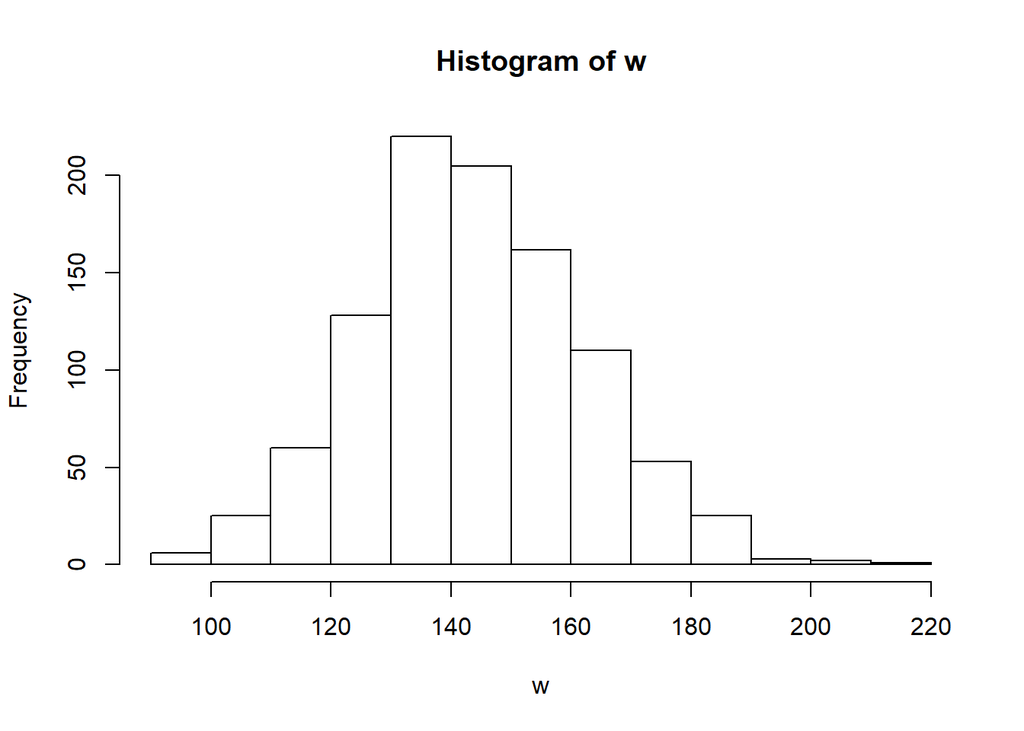

```r
#normal

hist(w)
```

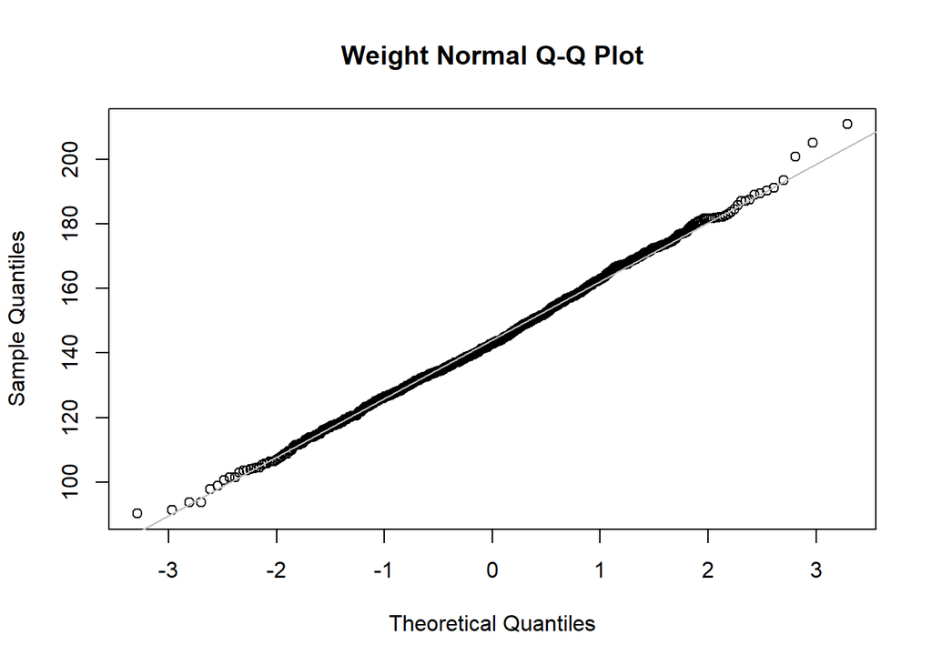

```r
qqnorm(w, main = "Weight Normal Q-Q Plot")
qqline(w, col = "gray")
```

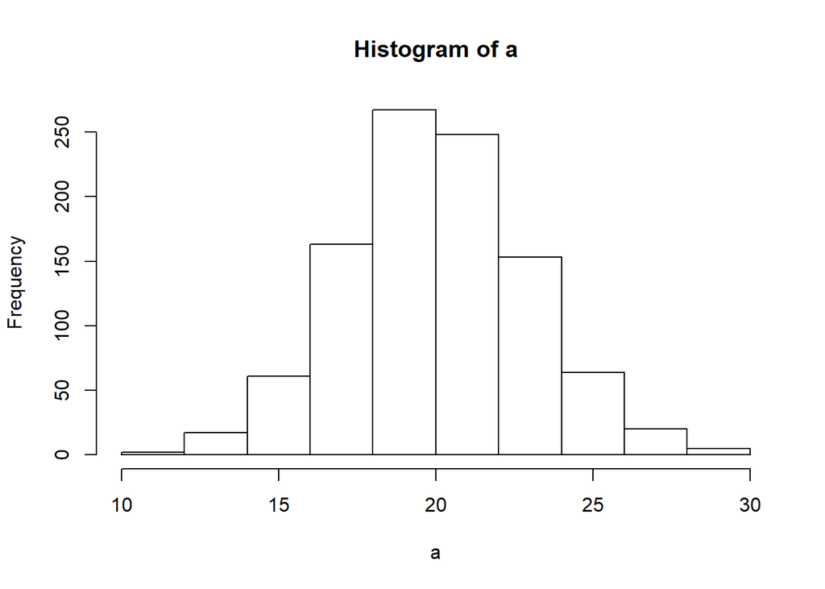

```r
#normal

hist(a)
```

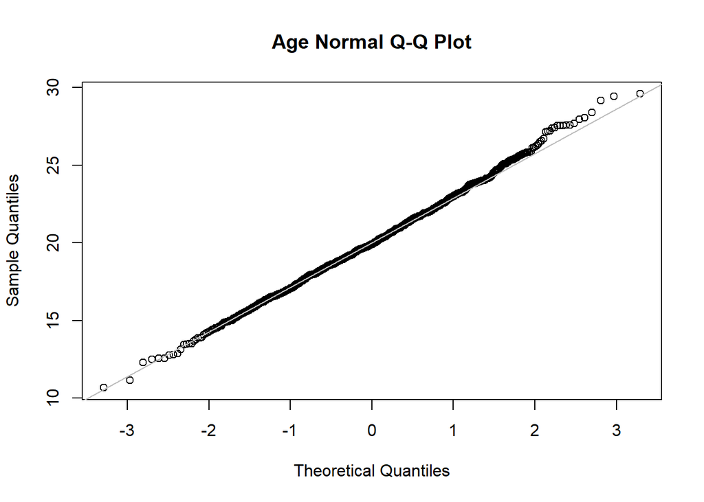

```r
qqnorm(a, main = "Age Normal Q-Q Plot")
qqline(a, col = "gray")
```

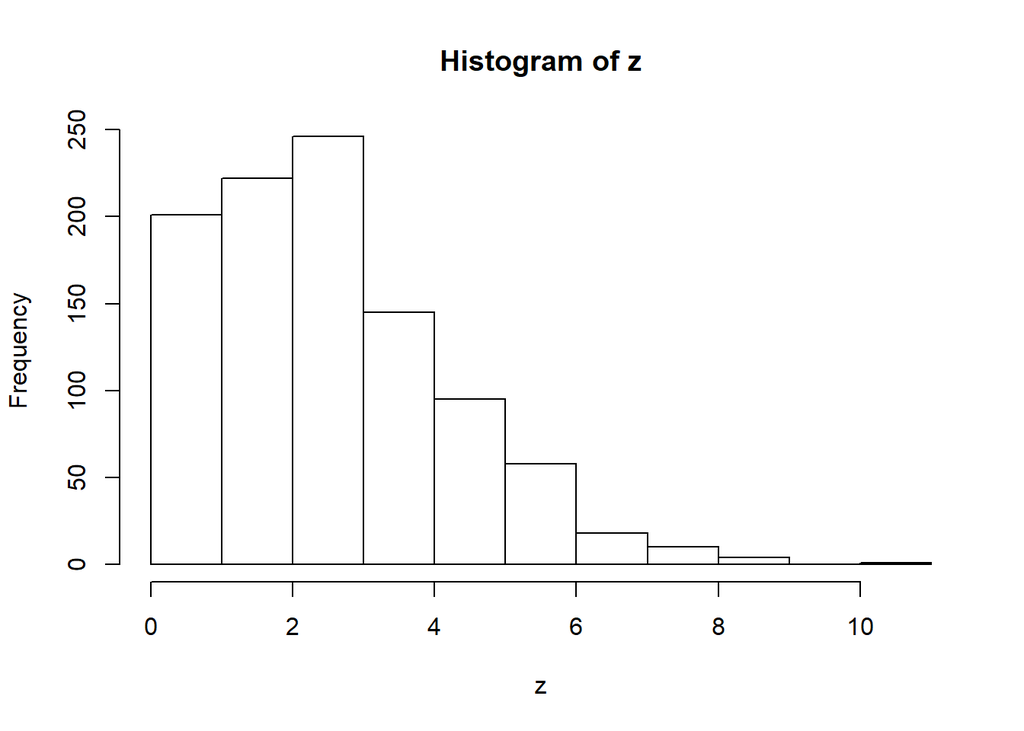

```r
#normal

hist(z)
```

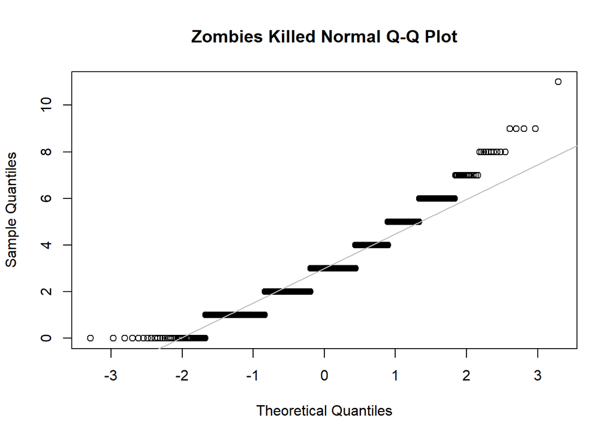

```r
qqnorm(z, main = "Zombies Killed Normal Q-Q Plot")
qqline(z, col = "gray")
```

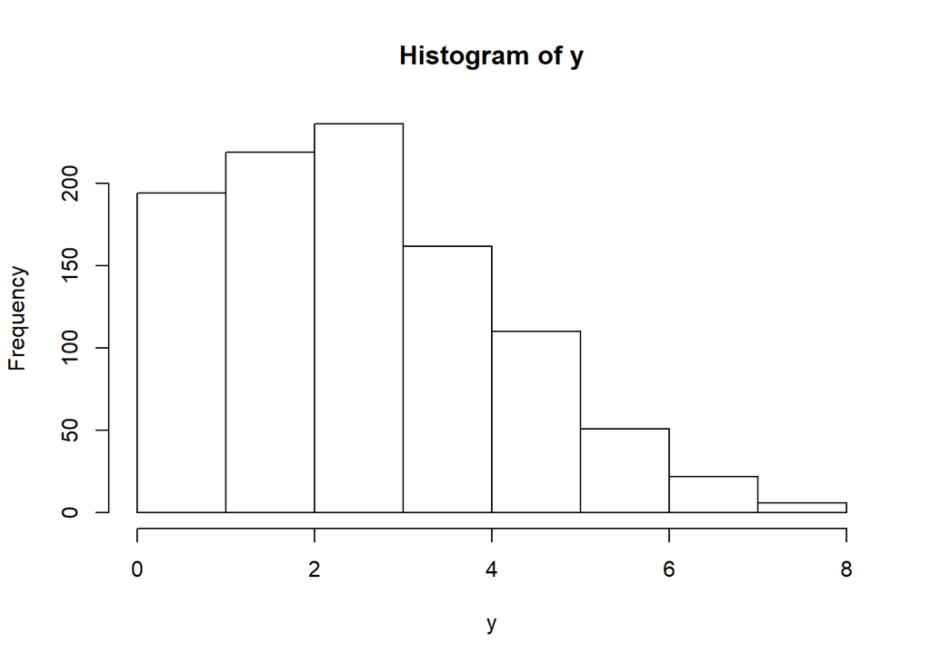

```r
#poisson

hist(y)
```

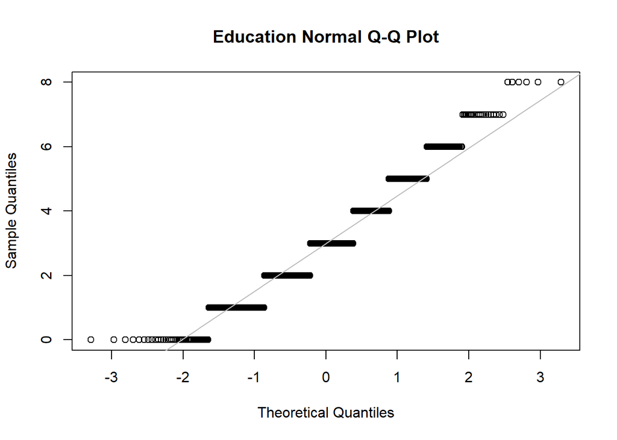

```r
qqnorm(y, main = "Education Normal Q-Q Plot")
qqline(y, col = "gray")
```

```r
#poisson
```

## Now use the sample() function to sample ONE subset of 30 zombies (without replacement) from this population and calculate the mean and sample standard deviation for each variable. Also estimate the standard error for each variable and construct the 95% confidence interval for each mean. Note that for the variables that are not drawn from the normal distribution, you will need to base your estimate of the CIs on some different distribution.

```r
k <- 1  # number of samples
n <- 30  # size of each sample
s <- NULL  # dummy variable to hold each sample
for (i in 1:k) {
    s[[i]] <- sample(h, size = n, replace = FALSE)
}

m <- NULL
for (i in 1:k) {
    m[i] <- mean(s[[i]])
}
mean(m)
```

```
## [1] 66.33097
```

```r
stdev <- NULL
for (i in 1:k) {
    stdev[i] <- sd(s[[i]])
}
sem <- stdev/sqrt(n)  # a vector of SEs estimated from each sample

upper <- mean(m) + qnorm(0.95, mean = mean(m), sd = stdev) * mean(sem)
lower <- mean(m) + qnorm(0.05, mean = mean(m), sd = stdev) * mean(sem)
ci <- c(lower, upper)
ci
```

```
## [1] 116.1746 129.1758
```

```r
####

k <- 1  # number of samples
n <- 30  # size of each sample
s <- NULL  # dummy variable to hold each sample
for (i in 1:k) {
    s[[i]] <- sample(w, size = n, replace = FALSE)
}

m <- NULL
for (i in 1:k) {
    m[i] <- mean(s[[i]])
}
mean(m)
```

```
## [1] 146.8876
```

```r
stdev <- NULL
for (i in 1:k) {
    stdev[i] <- sd(s[[i]])
}
sem <- stdev/sqrt(n)  # a vector of SEs estimated from each sample

upper <- mean(m) + qnorm(0.95, mean = mean(m), sd = stdev) * mean(sem)
lower <- mean(m) + qnorm(0.05, mean = mean(m), sd = stdev) * mean(sem)
ci <- c(lower, upper)
ci
```

```
## [1] 556.2043 785.4579
```

```r
####

k <- 1  # number of samples
n <- 30  # size of each sample
s <- NULL  # dummy variable to hold each sample
for (i in 1:k) {
    s[[i]] <- sample(a, size = n, replace = FALSE)
}

m <- NULL
for (i in 1:k) {
    m[i] <- mean(s[[i]])
}
mean(m)
```

```
## [1] 19.23024
```

```r
stdev <- NULL
for (i in 1:k) {
    stdev[i] <- sd(s[[i]])
}
sem <- stdev/sqrt(n)  # a vector of SEs estimated from each sample

upper <- mean(m) + qnorm(0.95, mean = mean(m), sd = stdev) * mean(sem)
lower <- mean(m) + qnorm(0.05, mean = mean(m), sd = stdev) * mean(sem)
ci <- c(lower, upper)
ci
```

```
## [1] 26.93834 32.09284
```

```r
####

k <- 1  # number of samples
n <- 30  # size of each sample
s <- NULL  # dummy variable to hold each sample
for (i in 1:k) {
    s[[i]] <- sample(z, size = n, replace = FALSE)
}

m <- NULL
for (i in 1:k) {
    m[i] <- mean(s[[i]])
}
mean(m)
```

```
## [1] 2.833333
```

```r
stdev <- NULL
for (i in 1:k) {
    stdev[i] <- sd(s[[i]])
}
sem <- stdev/sqrt(n)  # a vector of SEs estimated from each sample

upper <- mean(m) + qpois(0.95, lambda=mean(m), lower.tail = TRUE, log.p = FALSE) * mean(sem)
lower <- mean(m) + qpois(0.05, lambda=mean(m), lower.tail = TRUE, log.p = FALSE) * mean(sem)
ci <- c(lower, upper)
ci
```

```
## [1] 2.833333 4.786227
```

```r
####


k <- 1  # number of samples
n <- 30  # size of each sample
s <- NULL  # dummy variable to hold each sample
for (i in 1:k) {
    s[[i]] <- sample(y, size = n, replace = FALSE)
}

m <- NULL
for (i in 1:k) {
    m[i] <- mean(s[[i]])
}
mean(m)
```

```
## [1] 3
```

```r
stdev <- NULL
for (i in 1:k) {
    stdev[i] <- sd(s[[i]])
}
sem <- stdev/sqrt(n)  # a vector of SEs estimated from each sample

upper <- mean(m) + qpois(0.95, lambda=mean(m), lower.tail = TRUE, log.p = FALSE) * mean(sem)
lower <- mean(m) + qpois(0.05, lambda=mean(m), lower.tail = TRUE, log.p = FALSE) * mean(sem)
ci <- c(lower, upper)
ci
```

```
## [1] 3.339032 5.034191
```

## Now draw 99 more random samples of 30 zombies out and calculate the mean for each of the these samples. Together with the first sample you drew out, you now have a set of 100 means for each variable (each based on 30 observations), which constitutes a sampling distribution for each variable. What are the means and standard deviations of this distribution for each variable? How do the standard deviations compare to the standard errors estimated in [5]? What do these sampling distributions look like? Are they normally distributed? What about for those variables that you concluded were not originally drawn from a normal distribution?

```r
k <- 99  # number of samples
n <- 30  # size of each sample
s <- NULL  # dummy variable to hold each sample
for (i in 1:k) {
    s[[i]] <- sample(h, size = n, replace = FALSE)
}

m <- NULL
for (i in 1:k) {
    m[i] <- mean(s[[i]])
}
mean(m)
```

```
## [1] 67.67122
```

```r
stdev <- NULL
for (i in 1:k) {
    stdev[i] <- sd(s[[i]])
}
```